# Raport z eksperymentu: Czytelność wykresów

Maja Wojtysiak-Kotlarska

## Cel badania

Celem badania było sprawdzenie, czy klasyczne zasady wizualizacji danych – takie jak preferowanie wykresów słupkowych 2D nad kołowymi lub 3D, oraz unikanie nadmiaru kolorów – rzeczywiście poprawiają zrozumienie danych przez odbiorców.

Badanie składało się z trzech eksperymentów:

1. Porównanie wykresu kołowego i słupkowego w zadaniu oszacowania udziału grupy wiekowej 15–24.
2. Porównanie wykresu 3D i 2D w zadaniu oszacowania udziału działu IT w budżecie firmy.
3. Ocena subiektywnej czytelności wykresu jednokolorowego vs. wielokolorowego.

## Metodologia

Stworzono dwie wersje ankiety: - **Grupa kontrolna** otrzymała wykresy z błędami wizualnymi (kołowy, 3D, wielokolorowy). - **Grupa testowa** otrzymała wykresy zgodne z dobrymi praktykami (słupkowy 2D, jednokolorowy).

W każdej grupie wzięło udział 15 osób (łącznie 30 odpowiedzi).

## Opis danych zaprezentowanych na wykresach

W każdym z trzech eksperymentów wykorzystano realistyczne, ale kontrolowane zestawy danych. Dane zostały tak skonstruowane, aby były łatwe do interpretacji, a jednocześnie umożliwiały zbadanie wpływu formy wykresu na trafność oszacowania lub subiektywną ocenę.

### Eksperyment 1 – Struktura populacji według wieku

W tym eksperymencie uczestnikom zaprezentowano wykres przedstawiający strukturę demograficzną populacji podzieloną na pięć przedziałów wiekowych. Dane przedstawiono w postaci udziałów procentowych, które sumowały się do 100%. Zadaniem uczestnika było oszacowanie procentowego udziału grupy „15–24”.

**Rzeczywista wartość udziału grupy „15–24”: 12%**

| Grupa wiekowa | Udział (%) |
| --- | --- |
| 0–14 | 18 |
| 15–24 | 12 |
| 25–54 | 45 |
| 55–64 | 13 |
| 65+ | 12 |

- **Grupa kontrolna** widziała wykres **kołowy**, a **grupa testowa** wykres **słupkowy 2D**.
- Celem było zbadanie, który typ wykresu pozwala na trafniejsze oszacowanie proporcji.

### Eksperyment 2 – Udział działów w budżecie firmy

Dane w tym eksperymencie przedstawiały udziały czterech działów w całkowitym budżecie organizacji. Zadaniem uczestnika było oszacowanie udziału działu „IT”.

| Dział | Udział (%) |
| --- | --- |
| Sprzedaż | 40 |
| Marketing | 25 |
| IT | 20 |
| HR | 15 |

- **Grupa kontrolna** widziała wykres **kołowy 3D**, a **grupa testowa** wykres **słupkowy 2D**.
- Celem było sprawdzenie, czy wykres 3D zniekształca percepcję proporcji w porównaniu do wykresu płaskiego.

### Eksperyment 3 – Czytelność wykresu: liczba kroków

Uczestnikom zaprezentowano dwa wykresy słupkowe przedstawiające liczbę kroków wykonanych w ciągu dnia przez sześć różnych osób. Oba wykresy przedstawiały identyczne dane, ale różniły się zastosowaną kolorystyką.

**Zakres danych: 3520–8100 kroków**

| Osoba | Liczba kroków |
| --- | --- |
| Alicja | 7310 |
| Bartek | 5550 |
| Celina | 8100 |
| Damian | 6490 |
| Eliza | 7180 |
| Franek | 3520 |

- **Wykres A**: jednokolorowy (wszystkie słupki w jednym kolorze)
- **Wykres B**: wielokolorowy (każdy słupek w innym kolorze)
- Zadaniem uczestnika było wskazanie, który wykres był dla niego bardziej czytelny.

## Dane i analiza

Tabela 1: Odpowiedzi uczestników w trzech eksperymentach

| Grupa | Eksperyment.1 | Eksperyment.2 | Eksperyment.3 |
| --- | --- | --- | --- |
| Kontrolna | 20 | 18 | Wykres A |
| Kontrolna | 10 | 15 | Wykres B |
| Kontrolna | 12 | 20 | Wykres A |
| Kontrolna | 15 | 20 | Wykres B |
| Kontrolna | 15 | 15 | Wykres B |
| Kontrolna | 12 | 18 | Wykres A |
| Kontrolna | 10 | 20 | Wykres A |
| Kontrolna | 15 | 25 | Wykres B |
| Kontrolna | 15 | 20 | Wykres A |
| Kontrolna | 15 | 18 | Wykres A |
| Kontrolna | 15 | 15 | Wykres B |
| Kontrolna | 10 | 20 | Wykres B |
| Kontrolna | 12 | 20 | Wykres A |
| Kontrolna | 10 | 20 | Wykres B |
| Kontrolna | 10 | 15 | Wykres B |
| Testowa | 12 | 15 | Wykres A |
| Testowa | 12 | 20 | Wykres B |
| Testowa | 12 | 20 | Wykres A |
| Testowa | 13 | 20 | Wykres B |
| Testowa | 12 | 20 | Wykres A |
| Testowa | 12 | 18 | Wykres A |
| Testowa | 12 | 20 | Wykres A |
| Testowa | 12 | 20 | Wykres B |
| Testowa | 12 | 15 | Wykres A |
| Testowa | 12 | 20 | Wykres A |
| Testowa | 12 | 20 | Wykres B |
| Testowa | 12 | 18 | Wykres B |
| Testowa | 12 | 25 | Wykres A |
| Testowa | 10 | 20 | Wykres A |
| Testowa | 14 | 18 | Wykres B |

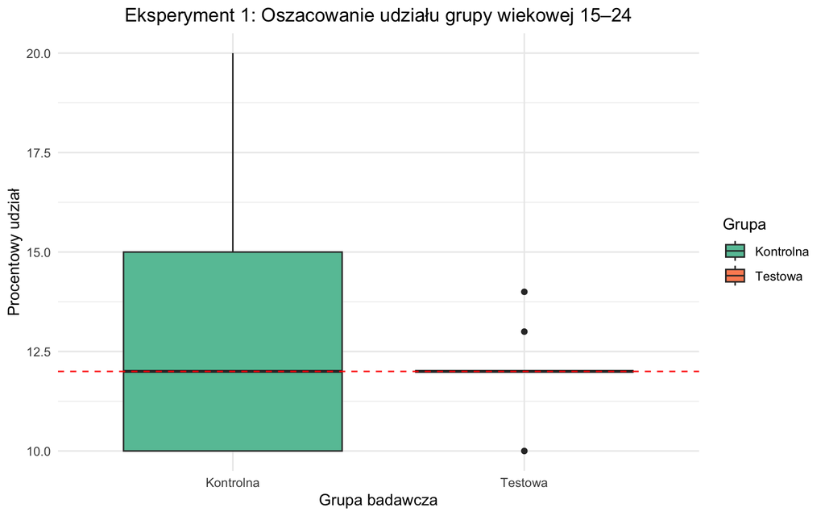

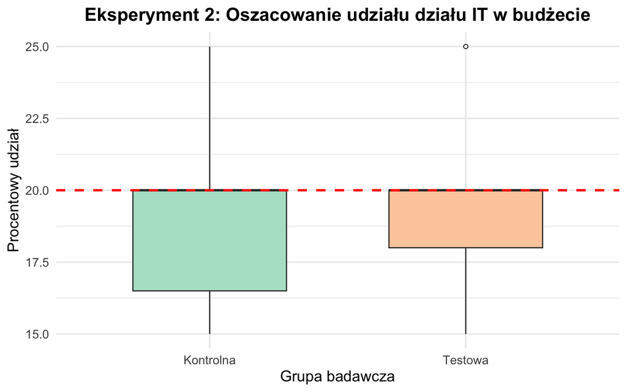

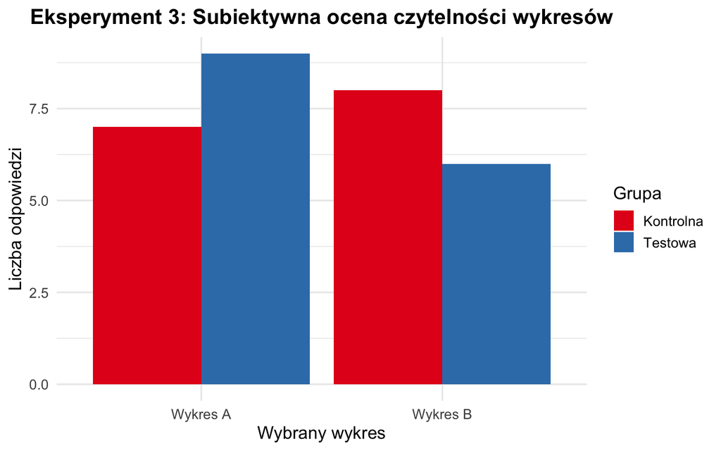

## Podsumowanie

Tabela: Statystyczne podsumowanie wyników

| Dane | Wartość |
| --- | --- |
| Średnia oszacowania (Eksperyment 1 – kontrolna) | 13.06667 |
| Średnia oszacowania (Eksperyment 1 – testowa) | 12.06667 |
| Średnia oszacowania (Eksperyment 2 – kontrolna) | 18.60000 |
| Średnia oszacowania (Eksperyment 2 – testowa) | 19.26667 |
| % wyboru ‘Wykres A’ (Eksperyment 3 – kontrolna) | 46.66667 |
| % wyboru ‘Wykres A’ (Eksperyment 3 – testowa) | 60.00000 |

## Wnioski

Wyniki sugerują, że zasady dobrej wizualizacji są nadal skuteczne i mają praktyczne zastosowanie.